# `SCPCL001114` - Exploration of gene set based methods for tumor cell assignment

Ally Hawkins

2024-07-17

## Introduction

In this notebook we attempt to identify tumor cells in `SCPCL001114` using the following marker gene based methods:

- Marker gene expression from `SCPCL000822` to inform an appropriate cut off for marker gene expression in `SCPCL000824`.
- [`AUCell`](https://www.bioconductor.org/packages/release/bioc/vignettes/AUCell/inst/doc/AUCell.html) with marker genes in both samples. These results were obtained from running through `aucell-annotation.sh`.
- [`UCell`](https://carmonalab.github.io/UCell_demo/UCell_matrix_vignette.html#content) with marker genes in both samples.

Throughout this notebook, we will use `SCPCL000822` as a reference. We have classified tumor cells to be those identified as tumor cells by both `InferCNV` and `CopyKAT` and validated those classifications in `SCPCL000822_tumor-cell-validation.Rmd`.

## Setup

```r
suppressPackageStartupMessages({
  # load required packages
  library(SingleCellExperiment)
  library(ggplot2)
})

# Set default ggplot theme
theme_set(
  theme_bw()
)

# quiet messages
options(readr.show_col_types = FALSE)
ComplexHeatmap::ht_opt(message = FALSE)
```

```r
# The base path for the OpenScPCA repository, found by its (hidden) .git directory
repository_base <- rprojroot::find_root(rprojroot::is_git_root)

# The current data directory, found within the repository base directory
data_dir <- file.path(repository_base, "data", "current")
sample_dir <- file.path(data_dir, "SCPCP000015", "SCPCS000752")

# The path to this module
module_base <- file.path(repository_base, "analyses", "cell-type-ewings")
```

```r
# source in helper functions: plot_gene_heatmap() and plot_cnv_heatmap()
# create_classification_df() and create_marker_gene_df()
validation_functions <- file.path(module_base, "scripts", "utils", "tumor-validation-helpers.R")
source(validation_functions)
```

```r
# Input files
sce_file <- file.path(sample_dir, "SCPCL001114_processed.rds")
marker_genes_file <- file.path(module_base, "references", "tumor-marker-genes.tsv")

# results from annotation workflow
results_dir <- file.path(module_base, "results", "aucell_annotation", "SCPCS000752")
auc_results_file <- file.path(results_dir, "SCPCL001114_auc-classifications.tsv")
marker_results_file <- file.path(results_dir, "SCPCL001114_marker-gene-classifications.tsv")
geneset_scores_file <- file.path(results_dir, "SCPCL001114_gene-set-scores.tsv")

# output files
final_annotations_dir <- file.path(module_base, "results", "annotation_tables", "SCPCS000752")
fs::dir_create(final_annotations_dir)
final_annotations_file <- file.path(final_annotations_dir, "SCPCL001114_tumor-classifications.tsv.gz")

# reference files to use
ref_sce_file <- file.path(data_dir, "SCPCP000015", "SCPCS000490", "SCPCL000822_processed.rds")
ref_labels_file <- file.path(module_base, "results", "annotation_tables", "SCPCS000490", "SCPCL000822_tumor-classifications.tsv.gz")
ref_geneset_scores_file <- file.path(module_base, "results", "cnv_annotation", "SCPCS000490", "SCPCL000822_gene-set-scores.tsv")
```

```r
# read in sce file
sce <- readr::read_rds(sce_file)
auc_results_df <- readr::read_tsv(auc_results_file)
geneset_scores_df <- readr::read_tsv(geneset_scores_file)
marker_results_df <- readr::read_tsv(marker_results_file)

# read in ref sce and ref annotations for comparing between samples
# ref is SCPCL000822
ref_sce <- readr::read_rds(ref_sce_file)
ref_labels_df <- readr::read_tsv(ref_labels_file)
ref_geneset_df <- readr::read_tsv(ref_geneset_scores_file)
```

```r
# generate classification df to use for plots
classification_df <- sce |>
  scuttle::makePerCellDF(use.dimred = "UMAP") |>
  # replace UMAP.1 with UMAP1
  dplyr::rename_with(
    \(x) stringr::str_replace(x, "^UMAP\\.", "UMAP")
  ) |>
  # get rid of excess columns
  dplyr::select(barcodes, UMAP1, UMAP2, singler_celltype_annotation) |>
  # join with previous annotations, singler results, and gene set scores
  dplyr::left_join(auc_results_df, by = "barcodes") |>
  dplyr::left_join(marker_results_df, by = "barcodes") |>
  dplyr::left_join(geneset_scores_df, by = "barcodes") |>
  # rename since we are going to be looking at multiple marker gene methods
  dplyr::rename(
    "one_marker_gene_classification" = marker_gene_classification
  )

# generate marker genes df
plot_markers_df <- create_marker_gene_df(
  sce,
  classification_df,
  marker_genes_file
)
```

## Using marker gene expression from `SCPCL000822` to define tumor cells in `SCPCL001114`

With `SCPCL000822` we had a clear separation between marker gene expression in tumor cells and normal cells because there was a bimodal distribution. First we will just compare the distribution of the raw marker gene expression in `SCPCL000822` and `SCPCL001114`. To do this, we will get the total marker gene expression by summing all marker genes in a cell and then plot the distribution.

```r
# look at the raw sum of marker gene expression in both 822 and 824
# first create marker genes df for ref sce
ref_classification_df <- ref_labels_df |>
  dplyr::rename("barcodes" = "cell_barcode")

ref_markers_df <- create_marker_gene_df(sce = ref_sce,
                                        classification_df = ref_classification_df,
                                        marker_genes_file) |>
  dplyr::mutate(sample = "SCPCL000822")

# combine all marker gene data for both samples into one df
combined_markers_df <- plot_markers_df |>
  dplyr::select(barcodes, gene_symbol, gene_expression, transformed_gene_expression, sum_raw_exp, sum_transformed_exp) |>
  dplyr::mutate(sample = "SCPCL001114") |>
  dplyr::bind_rows(ref_markers_df)
```

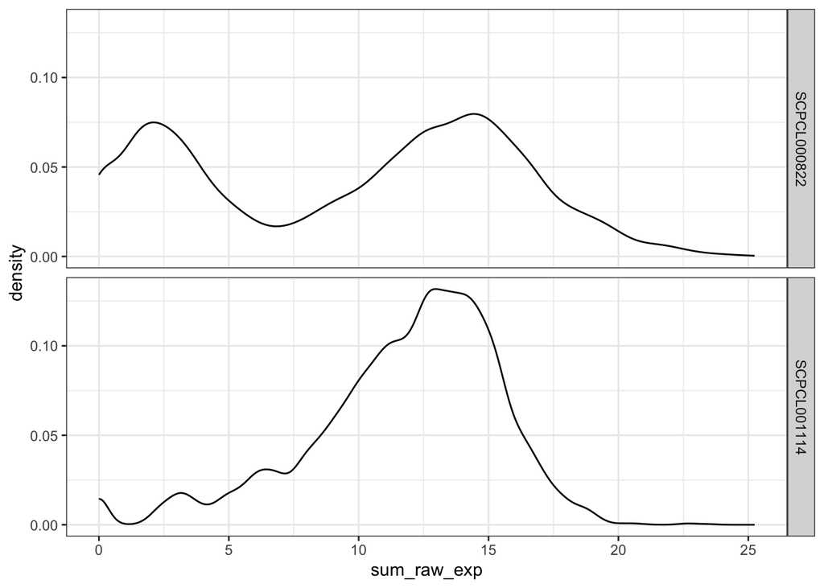

```r
# total distribution
ggplot(combined_markers_df, aes(x = sum_raw_exp)) +
  geom_density() +
  facet_grid(rows = vars(sample))
```

Looking at this, we see that `SCPCL000822` has a bimodal distribution, but this is not the case for `SCPCL001114`. Additionally, most of the distribution for `SCPCL001114` lies within the upper distribution for `SCPCL000822`. This would be consistent with our hypothesis that most of the cells in `SCPCL001114` are tumor cells. Let’s find the local minima in the bimodal distribution for `SCPCL000822` and then use that to classify tumor cells in `SCPCL001114`.

```r
# create distribution
density_data <- density(combined_markers_df$sum_raw_exp)
# find the local minima in the distribution
exp_cutoff <- optimize(approxfun(density_data$x, density_data$y), interval = c(1,10))$minimum
```

```r
# add new column with updated marker gene classification
# use local minima from 822 to define 1114
new_classification <- combined_markers_df |>
  dplyr::filter(sample == "SCPCL001114") |>
  dplyr::mutate(ref_marker_gene_classification = dplyr::if_else(sum_raw_exp >= exp_cutoff, "Tumor", "Normal")) |>
  dplyr::select(barcodes, ref_marker_gene_classification) |>
  unique()

# add new column to existing classification
classification_df <- classification_df |>
  dplyr::left_join(new_classification)
```

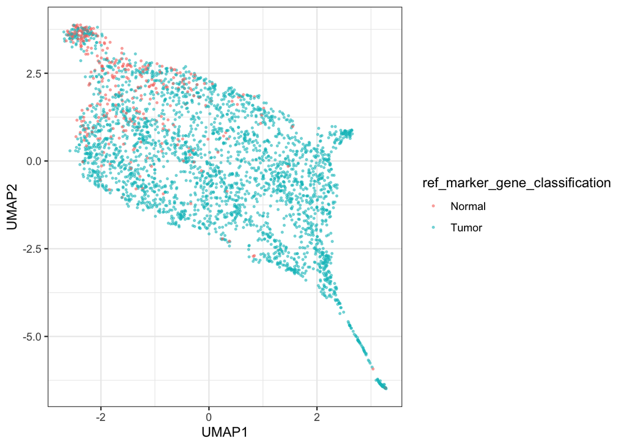

```r
# label cells based on new classifiation
ggplot(classification_df, aes(x = UMAP1, y = UMAP2, color = ref_marker_gene_classification)) +
  geom_point(alpha = 0.5, size = 0.5)
```

## Comparing gene set expression in `SCPCL000822` and `SCPCL001114`

Now we will look at the gene set scores for each gene set in `SCPCL000822` and `SCPCL001114`.  
The gene set scores for each cell are the mean normalized expression of all genes in a given gene set with no scaling.

We did not use these to classify `SCPCL000822`, so we won’t actually do any classification, but this will show us if the scores for tumor cells are similar to each other across samples.

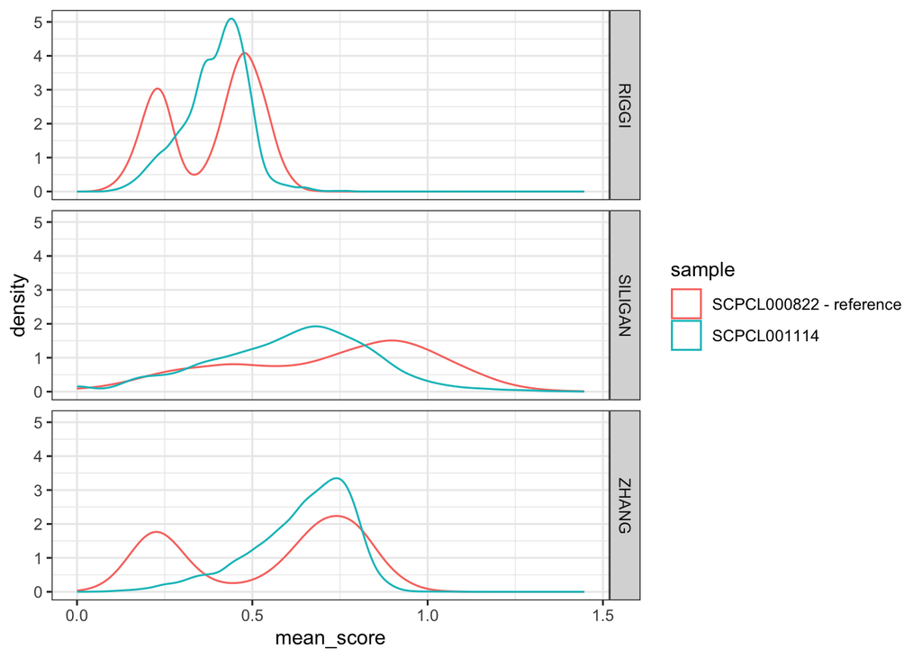

```r
# get geneset score from reference sce
ref_geneset_df <- ref_geneset_df |>
  dplyr::select(barcodes, starts_with("mean-")) |>
  tidyr::pivot_longer(
    cols = starts_with("mean-"),
    names_to = "geneset",
    values_to = "mean_score"
  ) |>
  dplyr::mutate(
    geneset = stringr::word(geneset, -1, sep = "-"),
    sample = "SCPCL000822 - reference"
  )

# plot gene set scores for each cell
geneset_plot_df <- classification_df |>
  dplyr::select(barcodes, UMAP1, UMAP2, ends_with("classification"), starts_with("mean-")) |>
  tidyr::pivot_longer(
    cols = starts_with("mean-"),
    names_to = "geneset",
    values_to = "mean_score"
  ) |>
  dplyr::mutate(
    geneset = stringr::word(geneset, -1, sep = "-")
  )

# join with gene set scores from 824 and plot distribution
geneset_plot_df |>
  dplyr::select(barcodes, geneset, mean_score) |>
  dplyr::mutate(sample = "SCPCL001114") |>
  dplyr::bind_rows(ref_geneset_df) |>
  ggplot(aes(x = mean_score, color = sample)) +
  geom_density() +
  facet_grid(rows = vars(geneset))
```

Again we see that the gene set scores are bimodal for `SCPCL000822`, at least for `RIGGI` and `ZHANG`. However, we don’t see that for `SCPCL001114`, but we do see that the majority of the distribution seems to line up with the upper distribution in `SCPCL000822`. Or at least this is the case for `RIGGI` and `ZHANG`. This makes me think that the majority of the cells are in fact tumor cells.

## Comparison to other classification methods

This section will compare using the marker gene cutoff determined from `SCPCL000822` to other classification methods. First we will compare the calls between each individual method and the marker gene method. Then, we will look at all methods together and plot the expression of marker genes and gene set scores for normal and tumor cells.

### `AUCell`

[`AUCell`](https://www.bioconductor.org/packages/release/bioc/vignettes/AUCell/inst/doc/AUCell.html) was run previously using the `aucell-annotation.sh` workflow. In that workflow, we ran `AUCell` on both a reference library, `SCPCL000822` and the query library, `SCPCL001114`. The AUC value determined by running `AUCell` with `SCPCL000822` was used as a cutoff for identifying tumor cells in `SCPCL001114`.

Here we will compare the classifications obtained by using `AUCell`. The classification using marker gene expression from `SCPCL000822` is the rows and the classification using `AUCell` is the columns.

```r
classification_df <- classification_df |>
  dplyr::mutate(
    ref_marker_gene_classification = forcats::fct_relevel(ref_marker_gene_classification, "Tumor"),
    auc_classification = forcats::fct_relevel(auc_classification, "Tumor")
  )

# compare using a confusion matrix
caret::confusionMatrix(
    table(
      classification_df$ref_marker_gene_classification,
      classification_df$auc_classification)
  )
```

```
## Confusion Matrix and Statistics
##
##
##          Tumor Normal
##   Tumor   2442    350
##   Normal     0    334
##
##                Accuracy : 0.888
##                  95% CI : (0.8765, 0.8989)
##     No Information Rate : 0.7812
##     P-Value [Acc > NIR] : < 2.2e-16
##
##                   Kappa : 0.5985
##
##  Mcnemar's Test P-Value : < 2.2e-16
##
##             Sensitivity : 1.0000
##             Specificity : 0.4883
##          Pos Pred Value : 0.8746
##          Neg Pred Value : 1.0000
##              Prevalence : 0.7812
##          Detection Rate : 0.7812
##    Detection Prevalence : 0.8932
##       Balanced Accuracy : 0.7442
##
##        'Positive' Class : Tumor
##
```

It looks like using `AUCell` results in more cells being called normal than with the marker gene cutoff determined by `SCPCL000822`.

### Expression of at least one marker gene

In the `aucell-annotation.sh` workflow, we looked at marker gene expression and classified any cell that expresses at least 1 marker gene as a tumor cell. Let’s compare the annotations obtained here using a cutoff determined by `SCPCL000822` to setting the cutoff of 1 marker gene.

First we will look at a confusion matrix between both methods. Here the updated classification based on `SCPCL000822` is the rows and the classification using expression of at least 1 marker gene is the columns.

```r
classification_df <- classification_df |>
  dplyr::mutate(
    one_marker_gene_classification = forcats::fct_relevel(one_marker_gene_classification, "Tumor")
  )

# compare using a confusion matrix
caret::confusionMatrix(
    table(
      classification_df$ref_marker_gene_classification,
      classification_df$one_marker_gene_classification)
  )
```

```
## Confusion Matrix and Statistics
##
##
##          Tumor Normal
##   Tumor   2792      0
##   Normal   293     41
##
##                Accuracy : 0.9063
##                  95% CI : (0.8955, 0.9163)
##     No Information Rate : 0.9869
##     P-Value [Acc > NIR] : 1
##
##                   Kappa : 0.2
##
##  Mcnemar's Test P-Value : <2e-16
##
##             Sensitivity : 0.9050
##             Specificity : 1.0000
##          Pos Pred Value : 1.0000
##          Neg Pred Value : 0.1228
##              Prevalence : 0.9869
##          Detection Rate : 0.8932
##    Detection Prevalence : 0.8932
##       Balanced Accuracy : 0.9525
##
##        'Positive' Class : Tumor
##
```

It looks like using `SCPCL000822` to define the cutoff results in more cells being called normal than with the strict cutoff of expressing at least 1 marker gene.

### Expression of at least two marker genes

Below we will look at classifying cells based on expression of two marker genes rather than one.

```r
# get list of tumor cells with > 2 marker genes expressed
tumor_cells <- plot_markers_df |>
  dplyr::mutate(gene_detected = as.integer(gene_expression > 0)) |>
  dplyr::group_by(barcodes) |>
  dplyr::summarize(total_genes = sum(gene_detected)) |>
  dplyr::filter(total_genes >= 2) |>
  dplyr::pull(barcodes)

classification_df <- classification_df |>
  dplyr::mutate(
    two_marker_gene_classification = dplyr::if_else(
      barcodes %in% tumor_cells,
      "Tumor",
      "Normal"
    ))
```

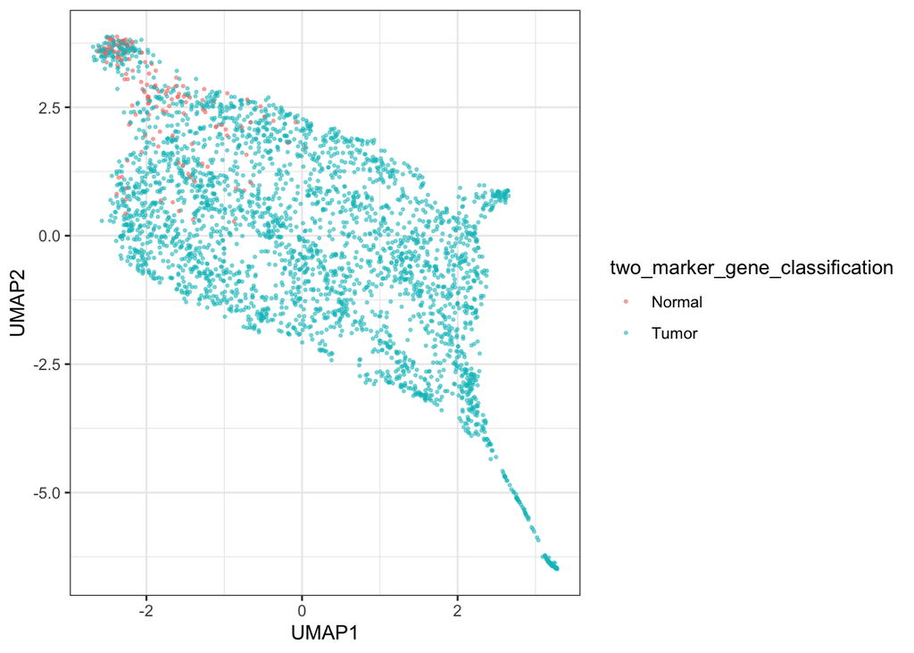

```r
ggplot(classification_df, aes(x = UMAP1, y = UMAP2, color = two_marker_gene_classification)) +
  geom_point(alpha = 0.5, size = 0.5)
```

Now let’s compare the annotations obtained using a cutoff determined by `SCPCL000822` to setting the cutoff of 2 marker genes. Here the updated classification based on `SCPCL000822` is the rows and the classification using expression of at least 2 marker genes is the columns.

```r
classification_df <- classification_df |>
  dplyr::mutate(
    two_marker_gene_classification = forcats::fct_relevel(two_marker_gene_classification, "Tumor")
  )

# compare using a confusion matrix
caret::confusionMatrix(
    table(
      classification_df$ref_marker_gene_classification,
      classification_df$two_marker_gene_classification)
  )
```

```
## Confusion Matrix and Statistics
##
##
##          Tumor Normal
##   Tumor   2792      0
##   Normal   194    140
##
##                Accuracy : 0.9379
##                  95% CI : (0.9289, 0.9461)
##     No Information Rate : 0.9552
##     P-Value [Acc > NIR] : 1
##
##                   Kappa : 0.5631
##
##  Mcnemar's Test P-Value : <2e-16
##
##             Sensitivity : 0.9350
##             Specificity : 1.0000
##          Pos Pred Value : 1.0000
##          Neg Pred Value : 0.4192
##              Prevalence : 0.9552
##          Detection Rate : 0.8932
##    Detection Prevalence : 0.8932
##       Balanced Accuracy : 0.9675
##
##        'Positive' Class : Tumor
##
```

It looks like using `SCPCL000822` to define the cutoff results in more cells being called normal than with the strict cutoff of expressing at least 2 marker genes.

### `UCell`

Here we will look at using [`UCell`](https://carmonalab.github.io/UCell_demo/UCell_matrix_vignette.html#content) to calculate a gene set score for each cell and then attempt to classify cells based on the distribution of those gene set scores.

```r
# get list of marker genes
marker_genes <- readr::read_tsv(marker_genes_file, show_col_types = FALSE) |>
  # account for genes being from multiple sources
  dplyr::select(cell_type, ensembl_gene_id, gene_symbol) |>
  dplyr::distinct() |>
  dplyr::filter(cell_type == "tumor") |>
  dplyr::pull(ensembl_gene_id)

# create list to use for ucell
ucell_gene_sets <- c(markers = list(marker_genes))

# run ucell on both ref (822) and 1114
ref_ucell <- UCell::ScoreSignatures_UCell(counts(ref_sce), features = ucell_gene_sets)
new_ucell <- UCell::ScoreSignatures_UCell(counts(sce), features = ucell_gene_sets)
```

`UCell` returns a signature score for each gene set and does not calculate any thresholds for classification on it’s own. We will look at the distribution of scores across both samples below and see if we can identify a good cut off to use for classification.

```r
# plot distribution of ucell scores for both samples
ref_ucell <- ref_ucell |>
  as.data.frame() |>
  tibble::rownames_to_column("barcodes") |>
  dplyr::mutate(sample = "SCPCL000822")

ucell_df <- new_ucell |>
  as.data.frame() |>
  tibble::rownames_to_column("barcodes") |>
  dplyr::mutate(sample = "SCPCL001114") |>
  dplyr::bind_rows(ref_ucell) |>
  tidyr::pivot_longer(ends_with("UCell"),
                      names_to = "gene_list",
                      values_to = "signature_score") |>
  dplyr::mutate(
    gene_list = stringr::word(gene_list, 1, sep = "_")
  )
```

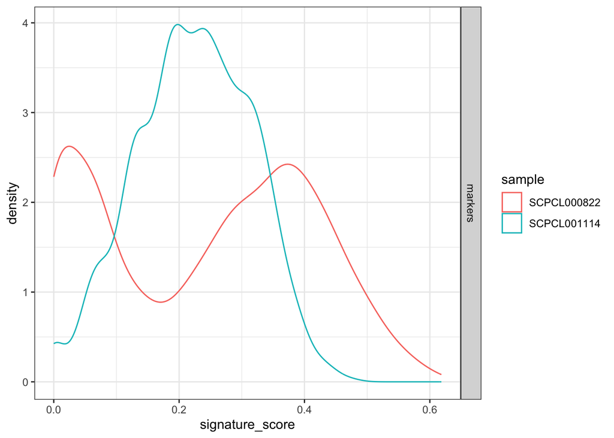

```r
ggplot(ucell_df, aes(x = signature_score, colour = sample)) +
  geom_density() +
  facet_grid(rows = vars(gene_list),
             scales = "free_y")
```

It looks like there is a bimodal distribution for `SCPCL000822` and not for `SCPCL001114` which is consistent with all the other marker gene methods we have looked at. However, here we see that the signature scores for `SCPCL001114` tend to fall in the middle of the upper and lower distribution for `SCPCL000822`. Because of this I don’t think using `UCell` for this library would be very helpful.

### Consensus between `AUCell` and marker genes

We already saw that all cells called as tumor in `AUCell` were also called as tumor using the marker gene cutoff from `SCPCL000822`. However, there are a group of normal cells that are called as tumor using marker genes but normal using `AUCell`. Here we will take the consensus between both methods. We will define any cells that are tumor in both as `Tumor`, normal in both as `Normal`, and any cells that are called differently in both as `Ambiguous`.

```r
# add new column with consensus to classification df
classification_df <- classification_df |>
  dplyr::mutate(consensus_classification = dplyr::case_when(
    ref_marker_gene_classification == "Tumor" & auc_classification == "Tumor" ~ "Tumor",
    ref_marker_gene_classification == "Normal" & auc_classification == "Normal" ~ "Normal",
    .default = "Ambiguous"
  ))
```

## Validate classifications from all methods

First let’s look at which cells are called tumor or normal on the UMAP across all classification methods.

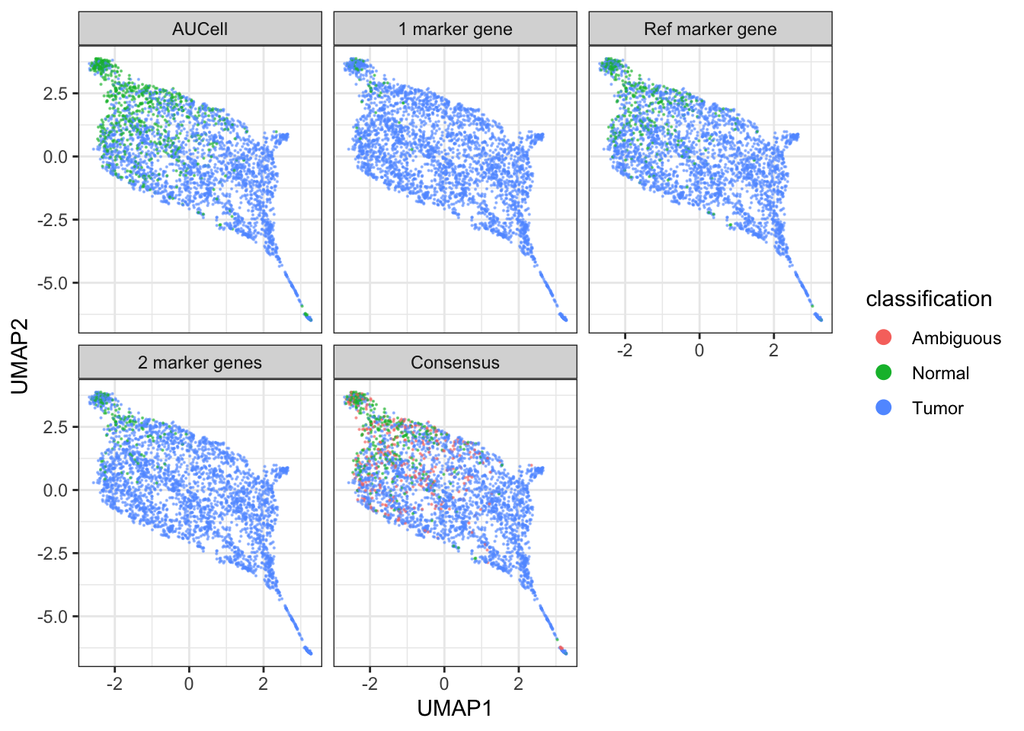

```r
method_levels <- c(
  "1 marker gene" = "one_marker_gene_classification",
  "2 marker genes" = "two_marker_gene_classification",
  "Ref marker gene" = "ref_marker_gene_classification",
  "AUCell" = "auc_classification",
  "Consensus" = "consensus_classification"
)

classification_df |>
  tidyr::pivot_longer(
    cols = ends_with("classification"),
    names_to = "method",
    values_to = "classification"
  ) |>
  dplyr::mutate(
    method = forcats::fct_recode(method, !!!method_levels),
    method = forcats::fct_relevel(method, "Consensus", after = Inf)) |>
  ggplot(aes(x = UMAP1, y = UMAP2, color = classification)) +
  geom_point(size = 0.1, alpha = 0.5) +
  facet_wrap(vars(method)) +
  guides(color = guide_legend(override.aes = list(size = 3, alpha = 1)))
```

Next, we compare the expression of marker genes and gene set scores across tumor and normal cells for each classification method. We expect to see higher expression of marker genes and gene set scores in tumor cells.

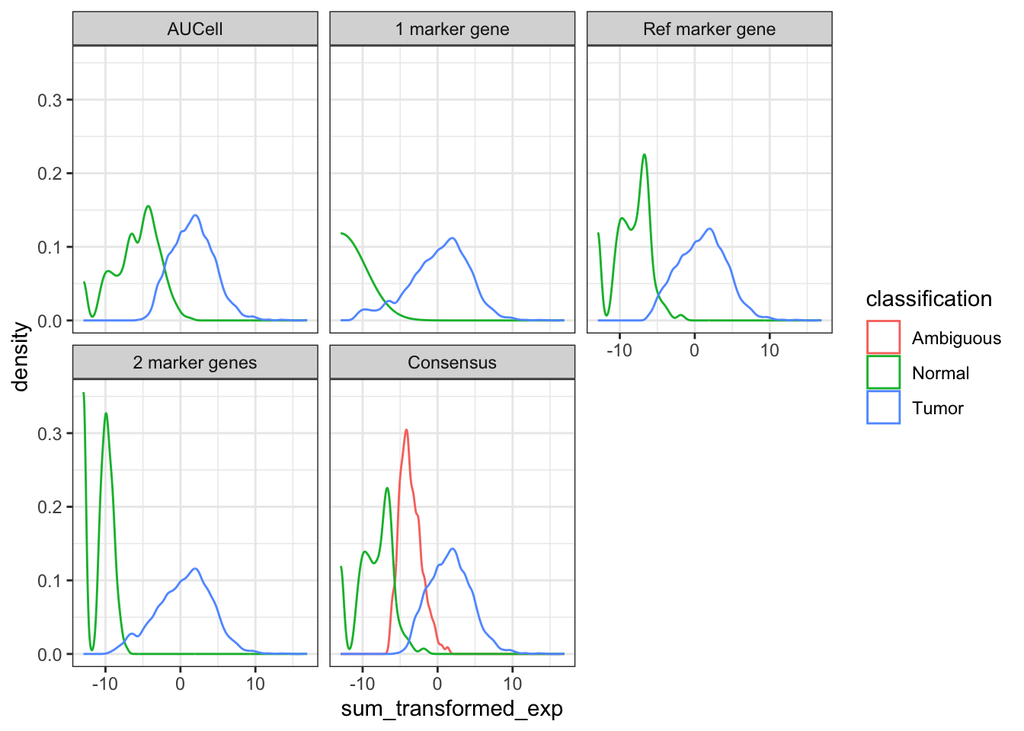

```r
# pull out any new classification methods we added
new_classification_df <- classification_df |>
  dplyr::select(barcodes, ref_marker_gene_classification, consensus_classification, two_marker_gene_classification)

# create a density plot showing the distribution of marker gene expression across classification methods
marker_density_df <- plot_markers_df |>
  # add new methods
  dplyr::left_join(new_classification_df, by = c("barcodes")) |>
  tidyr::pivot_longer(
    cols = ends_with("classification"),
    names_to = "method",
    values_to = "classification"
  ) |>
  dplyr::mutate(
    method = forcats::fct_recode(method, !!!method_levels),
    method = forcats::fct_relevel(method, "Consensus", after = Inf)
  )

ggplot(marker_density_df, aes(x = sum_transformed_exp, color = classification)) +
  geom_density() +
  facet_wrap(vars(method))
```

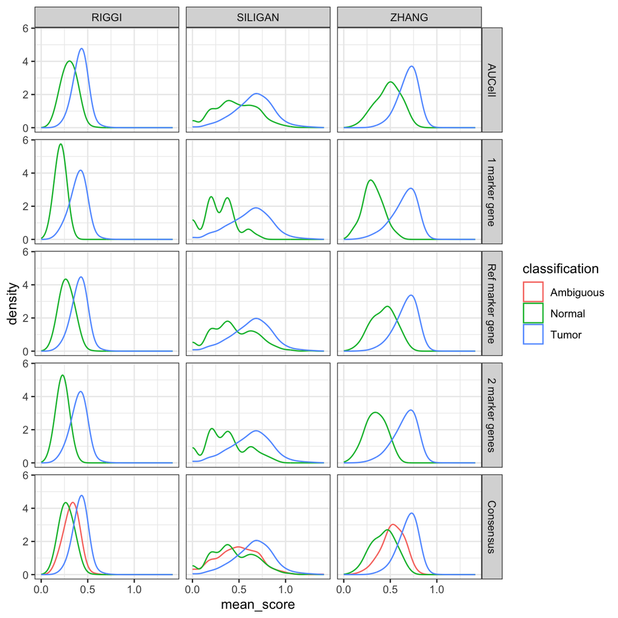

```r
geneset_plot_df |>
  # add new methods
  dplyr::left_join(new_classification_df, by = c("barcodes", "ref_marker_gene_classification")) |>
  tidyr::pivot_longer(
    cols = ends_with("classification"),
    names_to = "method",
    values_to = "classification"
  ) |>
  dplyr::mutate(
    method = forcats::fct_recode(method, !!!method_levels),
    method = forcats::fct_relevel(method, "Consensus", after = Inf)) |>
  ggplot(aes(x = mean_score, color = classification)) +
  geom_density(bw = 0.05) +
  facet_grid(rows = vars(method),
             cols = vars(geneset))
```

Looking at the above plots, we see the most distinct separation in either of the marker gene methods. `AUCell` appears to have the most overlap between distributions in normal and tumor cells. We also see that the consensus shows the “ambiguous” cells falling right in the middle. This tells us that the group of cells being called normal in `AUCell` and tumor in the marker gene methods that appear to have lower expression than those that are called tumor by both.

We can look at the same information but on an individual cell level. In the below plots we expect to see some separate clustering of tumor and normal cells.

```r
# create annotation df, keeping all classification methods
annotation_df <- classification_df |>
  dplyr::select(barcodes, ends_with("classification")) |>
  unique()

plot_colors <- c("Tumor" = "#00274C", "Normal" = "#FFCB05", "Ambiguous" = "grey")

annotation <- ComplexHeatmap::columnAnnotation(
  one_marker = annotation_df$one_marker_gene_classification,
  two_marker = annotation_df$two_marker_gene_classification,
  ref_marker_genes = annotation_df$ref_marker_gene_classification,
  AUCell = annotation_df$auc_classification,
  consensus = annotation_df$consensus_classification,
  col = list(one_marker = plot_colors,
             two_marker = plot_colors,
             ref_marker_genes = plot_colors,
             AUCell = plot_colors,
             consensus = plot_colors))
```

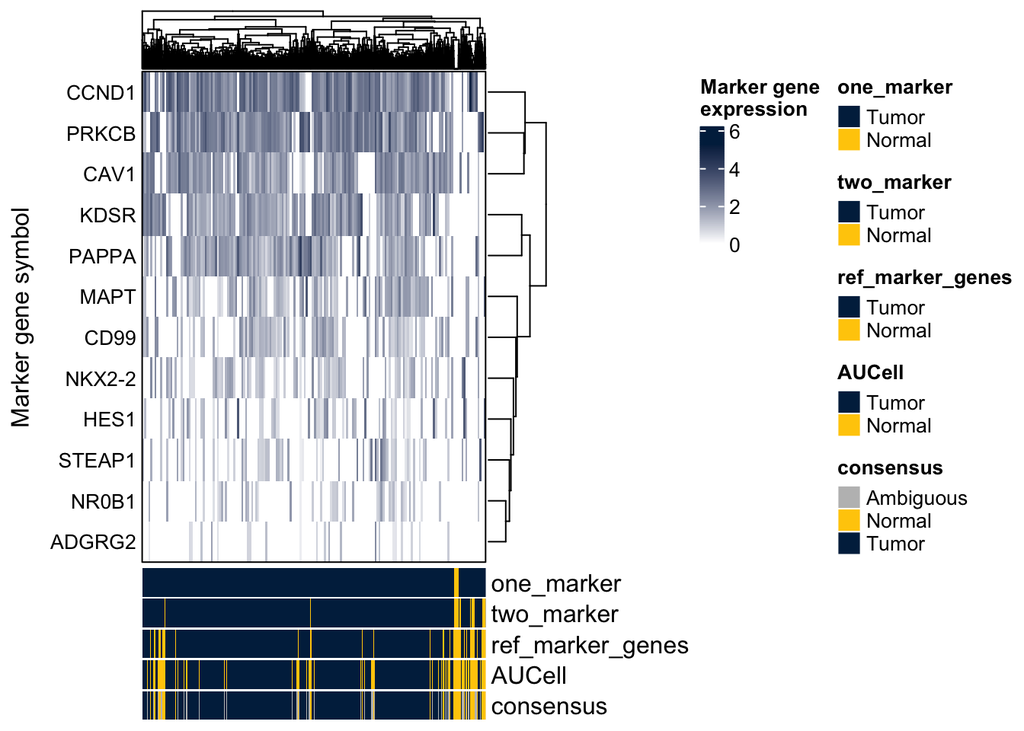

```r
# create matrix with marker genes as rows and barcodes as columns
marker_gene_heatmap <- plot_markers_df |>
  dplyr::select(gene_expression, gene_symbol, barcodes) |>
  tidyr::pivot_wider(values_from = gene_expression,
                     names_from = barcodes) |>
  tibble::column_to_rownames("gene_symbol") |>
  as.matrix()

# plot heatmap of marker genes
plot_gene_heatmap(marker_gene_heatmap,
                  row_title = "Marker gene symbol",
                  legend_title = "Marker gene \nexpression",
                  annotation = annotation)
```

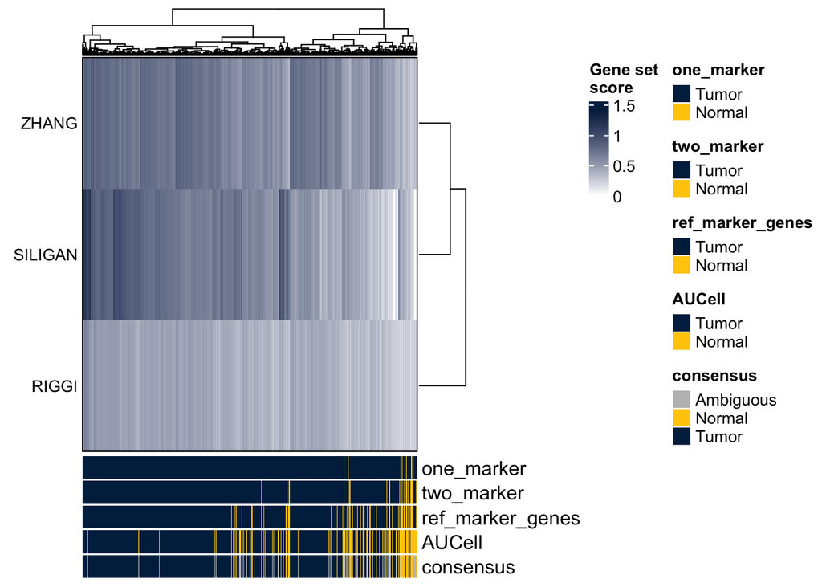

```r
# make a matrix of gene set by barcode
geneset_heatmap <- geneset_plot_df |>
  dplyr::select(mean_score, geneset, barcodes) |>
  unique() |>
  tidyr::pivot_wider(values_from = mean_score,
                     names_from = barcodes) |>
  tibble::column_to_rownames("geneset") |>
  as.matrix()

# plot heatmap of gene set score
plot_gene_heatmap(geneset_heatmap,
                  annotation = annotation,
                  legend_title = "Gene set \nscore")
```

Again we see that the ambigous cells tend to lie in the middle between tumor and normal cells. We also see that `AUCell` probably has the most “normal” cells that are mixing in with the tumor cells, while using a strict marker gene cutoff of expressing 1 marker gene leads to the biggest separation.

Moving forward I tend to favor using either just the reference based marker gene cutoff or the consensus between that and `AUCell`. Because we see such variable expression in our marker genes, I’m not sold on the idea of setting a firm cutoff at expression of 1 gene, while the other methods look at expression of all genes together.

## Export results

We will save the classification from all methods for future use.

```r
# export final TSV with annotations
classifications_output <- classification_df |>
  dplyr::select(
    cell_barcode = barcodes,
    one_marker_gene_classification,
    two_marker_gene_classification,
    ref_marker_gene_classification,
    auc_classification,
    consensus_classification
  )

readr::write_tsv(classifications_output, final_annotations_file)
```